# STAN Estimation

Bo Werth

2015-04-01

## General

STAN combines time series from National Accounts by economic activity. The estimation methodology consists of three major components:

- link series using growth rates
- increase detail by appling shares from secondary sources to aggregates of the main data source
- top-down adjustment to ensure consistency on all levels of the industry hierarchy

## Data Requirements

The data needs to meet the following requirements:

### Data for estimation

- variables in columns: `cou`, `var`, `ind`, `year`, `value`, `sou` (order does not matter)

## Extend

If the time coverage of our primary data source is insufficient and a secondary source covers for example more recent years, we attempt to extend the main source using the annual growth rate of the secondary source for years missing in the main source.

$estim_{t+1} = main_{t} * \frac{sec_{t+1}}{sec_{t}}$

In the example below, the sources are as follows:

- Primary source: STANandBTDi3
- Secondary source: STANandBTDi4
- Estimated source: NAPATCH

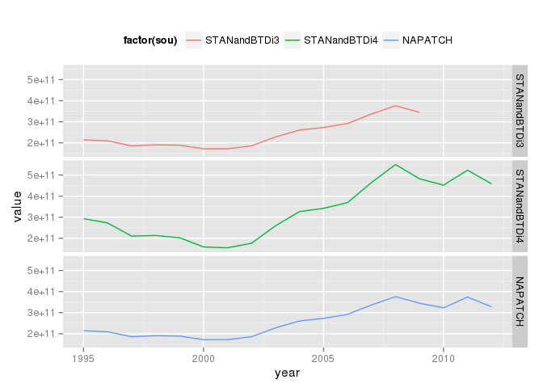

The dataset structure for this example looks as follows:

| cou | var | ind | year | value | sou |
| --- | --- | --- | --- | --- | --- |
| AUT | VALU | CTOTAL | 1995 | 2.146e+11 | STANandBTDi3 |
| AUT | VALU | CTOTAL | 1996 | 2.095e+11 | STANandBTDi3 |
| AUT | VALU | CTOTAL | 1997 | 1.859e+11 | STANandBTDi3 |
| AUT | VALU | CTOTAL | 1998 | 1.908e+11 | STANandBTDi3 |
| AUT | VALU | CTOTAL | 1999 | 1.891e+11 | STANandBTDi3 |
| AUT | VALU | CTOTAL | 2000 | 1.719e+11 | STANandBTDi3 |

## Apply distribution from secondary sources

In case our data primary source is not sufficiently detailed and additional detail is available in a secondary source, we attempt to apply the distribution from the secondary source to the primary source.

[figure not shown]

In the example below, the sources are as follows:

- Primary source: STANandBTDi3
- Secondary source: INDSTAT32
- Estimation results: NAPATCH

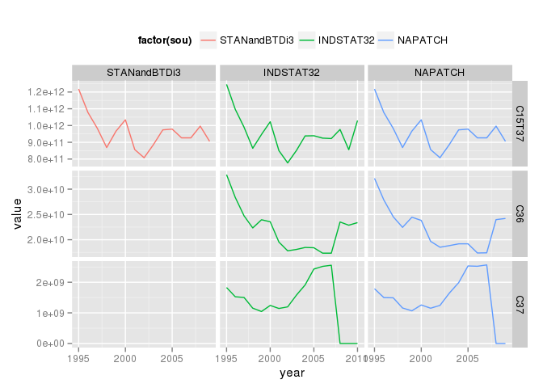

In this example we observe two oddities:

- the primary sources stops in 2009, therefore the estimated results don’t extend beyond
- the secondary source contains zeros in 2008-2010 and this is transferred to the estimated results

The dataset structure for this example looks as follows:

| cou | var | ind | year | value | sou |
| --- | --- | --- | --- | --- | --- |
| JPN | VALU | C15T37 | 1995 | 1.218e+12 | STANandBTDi3 |
| JPN | VALU | C15T37 | 1996 | 1.077e+12 | STANandBTDi3 |
| JPN | VALU | C15T37 | 1997 | 9.833e+11 | STANandBTDi3 |
| JPN | VALU | C15T37 | 1998 | 8.686e+11 | STANandBTDi3 |
| JPN | VALU | C15T37 | 1999 | 9.668e+11 | STANandBTDi3 |
| JPN | VALU | C15T37 | 2000 | 1.034e+12 | STANandBTDi3 |

The industries correspond to:

| ind | label |
| --- | --- |
| C15T37 | Manufacturing |
| C36 | Manufacturing n.e.c. |
| C37 | Recycling |

## Adjust

Numbers are adjusted top-down to ensure consitency with the total economy time series according to the hierarchy below:

- CTOTAL Total
  - C01T05 Agriculture, hunting, forestry and fishing
    - C01T02 Agriculture, hunting and forestry
      - C01 Agriculture, hunting and related service….
      - C02 Forestry, logging and related service ac….
    - C05 Fishing, fish hatcheries, fish farms and rel….
  - C10T41 Industry including energy
    - C10T14 Mining and quarrying
      - C10T12 Mining and quarrying of energy producing….
        - C10 Mining of coal and lignite, extracti….
        - C11 Extraction of crude petroleum and na….
        - C12 Mining of uranium and thorium ores
      - C13T14 Mining and quarrying except energy produ….
        - C13 Mining of metal ores
        - C14 Other mining and quarrying
    - C15T37 Manufacturing
      - C15T16 Food products, beverages and tobacco
        - C15 Food products and beverages
        - C16 Tobacco products
      - C17T19 Textiles, textile products, leather and ….
        - C17T18 Textiles and textile products
          - C17 Textiles
          - C18 Wearing apparel, dressing and dy….
        - C19 Leather, leather products and footwear
      - C20T22 Wood, paper, paper products, printing an….
        - C20 Wood and products of wood and cork
        - C21T22 Pulp, paper, paper products, printin….
          - C21 Pulp, paper and paper products
          - C22 Printing and publishing
      - C23T26 Chemicals and non-metallic mineral products
        - C23 Coke, refined petroleum products and….
        - C24 Chemicals and chemical products
        - C25 Rubber and plastics products
        - C26 Other non-metallic mineral products
      - C27T28 Basic metals and fabricated metal products
        - C27 Basic metals
        - C28 Fabricated metal products, except ma….
      - C29 Machinery and equipment, n.e.c.
      - C30T33 Electrical and optical equipment
        - C30T33X Computer, electronic and optical equ….
          - C30 Office, accounting and computing….
        - C31 Electrical machinery and apparatus, ….
          - C32 Radio, television and communicat….
          - C33 Medical, precision and optical i….
      - C34T35 Transport equipment
        - C34 Motor vehicles, trailers and semi-tr….
        - C35 Other transport equipment
      - C36T37 Manufacturing n.e.c. and recycling
        - C36 Manufacturing n.e.c.
        - C37 Recycling
    - C40T41 Electricity gas and, water supply
      - C40 Electricity, gas, steam and hot water supply
      - C41 Collection, purification and distributio….
  - C45 Construction
  - C50T64 Wholesale and retail trade - restaurants and hot….
    - C50T55 Wholesale and retail trade - restaurants and….
      - C50T52 Wholesale and retail trade - repairs
        - C50 Sale, maintenance and repair of moto….
        - C51 Wholesale, trade and commission excl….
        - C52 Retail trade excl. motor vehicles - ….
      - C55 Hotels and restaurants
    - C60T64 Transport, storage and communications
      - C60T63 Transport and storage
        - C60 Land transport - transport via pipelines
        - C61 Water transport
        - C62 Air transport
        - C63 Supporting and auxiliary transport a….
      - C64 Post and telecommunications
  - C65T99 Finance, insurance, real estate and business ser….
    - C65T74 Finance, insurance, real estate and business….
      - C65T67 Financial intermediation
        - C65 Financial intermediation, except ins….
        - C66 Insurance and pension funding, excep….
        - C67 Activities auxiliary to financial in….
      - C70T74 Real estate, renting and business activities
        - C70 Real estate activities
        - C71T74 Renting of mach. and equip. - other ….
          - C71 Renting of machinery and equipment
          - C72 Computer and related activities
          - C73T74 Research and development and oth….
            - C73 Research and development
            - C74 Other business activities
    - C75T99 Community, social and personal services
      - C75 Public admin. and defence - compulsory s….
      - C80T93 Education, Health and social work, other….
        - C80 Education
        - C85 Health and social work
        - C90T93 Other community, social and personal….
          - C90 Sewage and refuse disposal, sani….
          - C91 Activities of membership organiz….
          - C92 Recreational, cultural and sport….
          - C93 Other service activities
      - C95 Private households with employed persons
      - C99 Extra-territorial organizations and bodies